# Assignment 3a

#### Facets

1. What happens if you facet on a continuous variable?

Answer: A continous variable creates multiple facets for all the unique values.

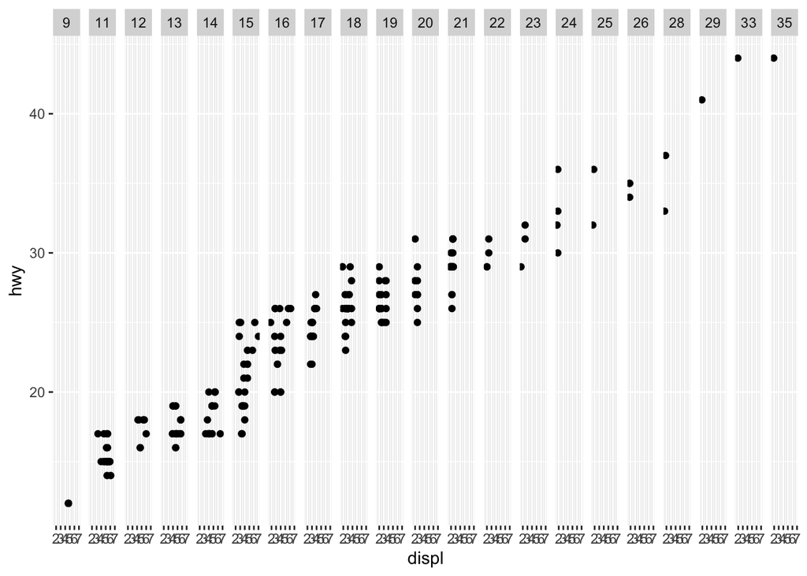

```r
ggplot(data = mpg) + geom_point(mapping = aes(x = displ, y = hwy)) + facet_grid(. ~ cty)
```

A continous variable creates multiple facets for all the unique values.

2. What do the empty cells in a plot with facet_grid(drv ~ cyl) mean? How do they relate to this plot?

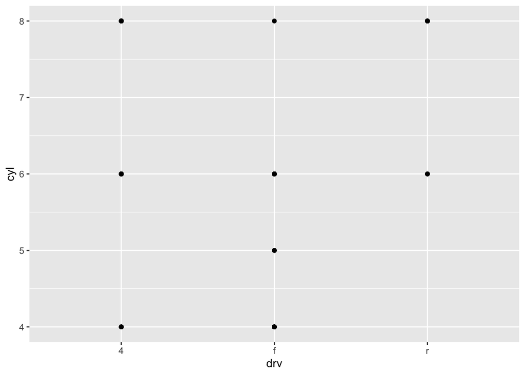

```r
ggplot(data = mpg) +
   geom_point(mapping = aes(x = drv, y = cyl))
```

Answer: It means that the empty cells are present as there is no value that represents the relationship between drv and cyl.

3. What plots does the following code make? What does . do?

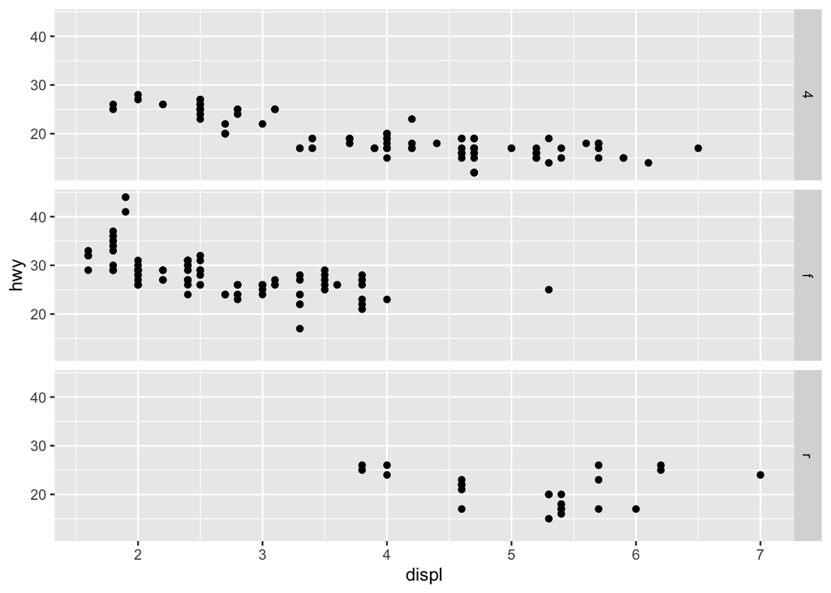

```r
ggplot(data = mpg) +
geom_point(mapping = aes(x = displ, y = hwy)) +
facet_grid(drv ~ .)
```

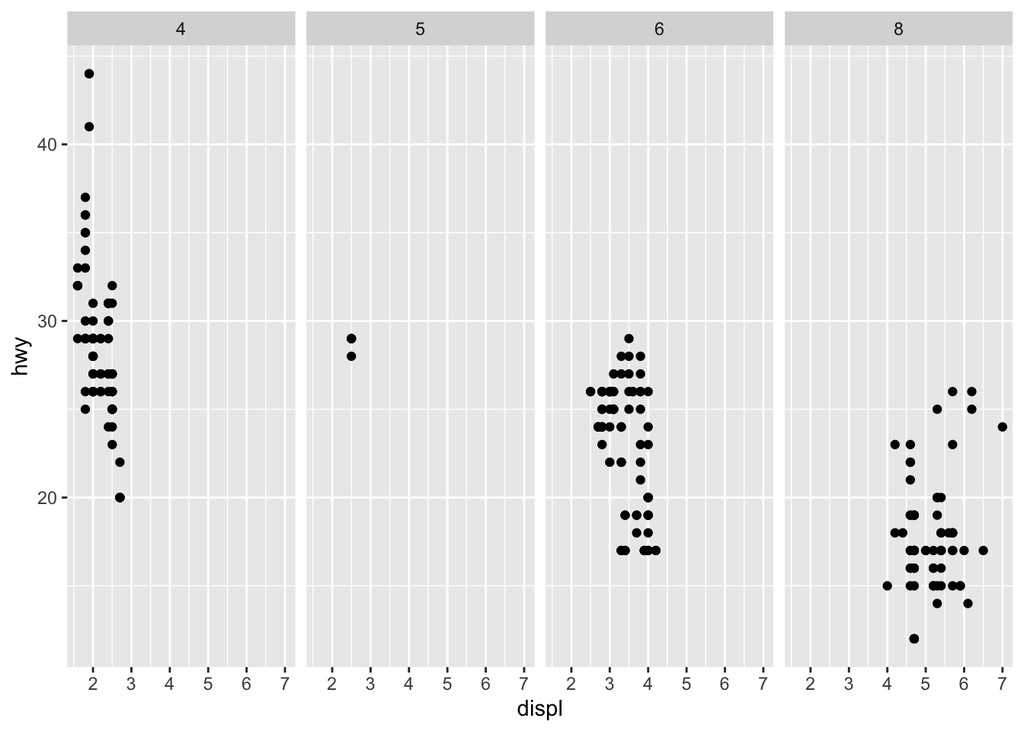

```r
ggplot(data = mpg) +
geom_point(mapping = aes(x = displ, y = hwy)) +
facet_grid(. ~ cyl)
```

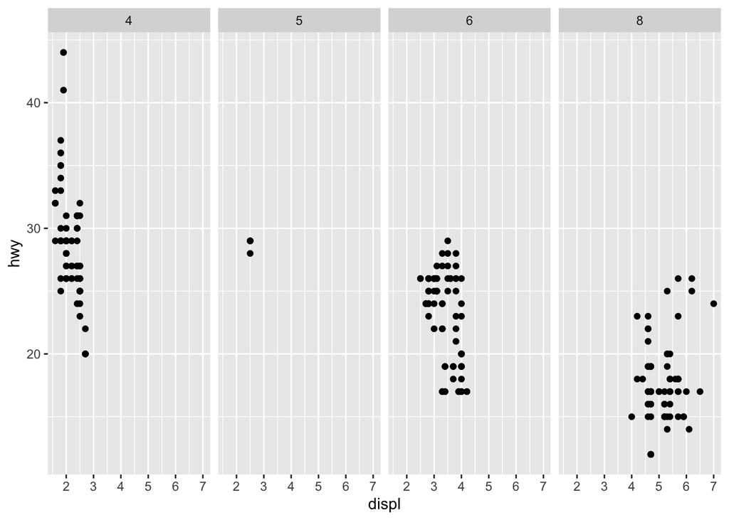

```r
ggplot(data = mpg) +
geom_point(mapping = aes(x = displ, y = hwy)) +
facet_grid(. ~ cyl)
```

4. Take the first faceted plot in this section:

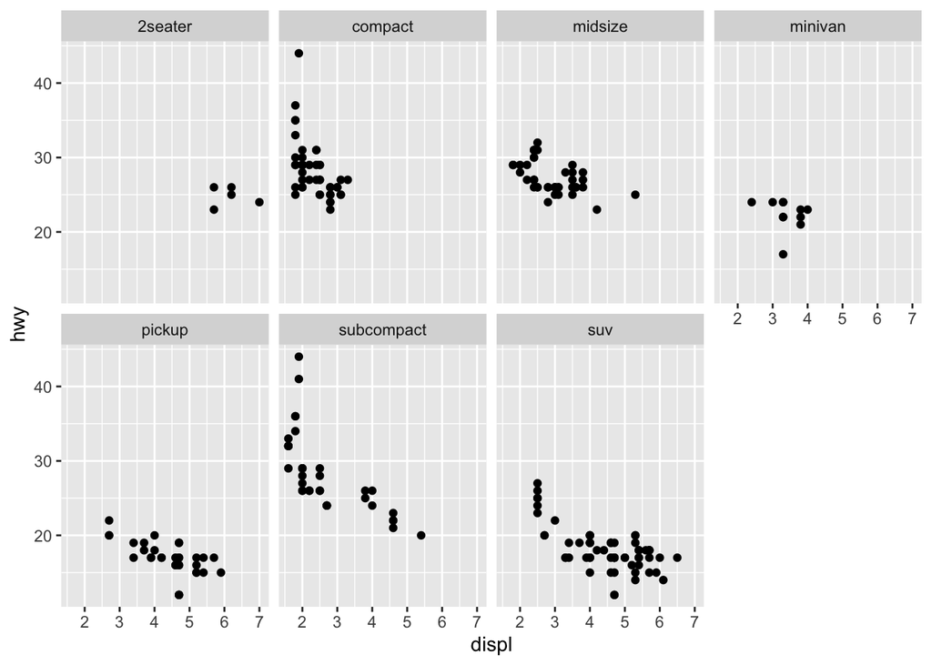

```r
ggplot(data = mpg) +
geom_point(mapping = aes(x = displ, y = hwy)) +
facet_wrap(~ class, nrow = 2)
```

What are the advantages to using faceting instead of the color aesthetic? What are the disadvantages? How might the balance change if you had a larger dataset?

Answer: It is difficult to resolve more than a dozen or so discrete colours, but we can have a larger number of facets than that. On the other hand, facets can be harder to read at a glance, or if the cells being compared aren’t lined up in the required dimension. So in a situation like this, colours are probably better, but if we had more classes, or wanted to use colour for a different variable, facets would come into their own.